# League History and Analysis for "Fantasy Football Fun" / "Our Favorite Time of Year" 2005-2022

Summary table for all years combined regular season stats. Each column is has its own gradient to show highs and lows within the column.

| manager_name | wins | losses | ties | pts_for | pts_against | gms | win_% | ppg | ppg_a |
| --- | --- | --- | --- | --- | --- | --- | --- | --- | --- |
| Alyse | 21 | 19 | 1 | 3851 | 3947 | 41 | 52.44 | 93.93 | 96.27 |
| bulls | 3 | 10 | 1 | 1160 | 1253 | 14 | 25.00 | 82.86 | 89.50 |
| Chad | 84 | 80 | 3 | 15744 | 15875 | 167 | 51.20 | 94.28 | 95.06 |
| Dawn | 143 | 103 | 4 | 24406 | 22953 | 250 | 58.00 | 97.62 | 91.81 |
| Derek | 131 | 117 | 2 | 23481 | 23105 | 250 | 52.80 | 93.92 | 92.42 |
| Jake | 97 | 95 | 2 | 17565 | 18117 | 194 | 50.52 | 90.54 | 93.39 |
| Jared | 116 | 103 | 3 | 21251 | 20718 | 222 | 52.93 | 95.73 | 93.32 |
| Jarick | 124 | 122 | 4 | 23122 | 22768 | 250 | 50.40 | 92.49 | 91.07 |
| Jessica | 74 | 100 | 6 | 16570 | 17245 | 180 | 42.78 | 92.06 | 95.81 |
| Josh | 116 | 103 | 3 | 20869 | 20839 | 222 | 52.93 | 94.00 | 93.87 |
| Justine | 64 | 84 | 4 | 13665 | 14529 | 152 | 43.42 | 89.90 | 95.59 |
| Kelly | 52 | 60 | 0 | 10126 | 9935 | 112 | 46.43 | 90.41 | 88.71 |
| Kole | 26 | 14 | 2 | 3926 | 3738 | 42 | 64.29 | 93.48 | 89.00 |
| Matt | 22 | 19 | 1 | 3679 | 3738 | 42 | 53.57 | 87.60 | 89.00 |
| OffTheChain | 6 | 8 | 0 | 1287 | 1261 | 14 | 42.86 | 91.93 | 90.07 |
| Philly Cheese | 9 | 5 | 0 | 1260 | 1111 | 14 | 64.29 | 90.00 | 79.36 |
| Russ | 116 | 131 | 3 | 23226 | 23238 | 250 | 47.00 | 92.90 | 92.95 |
| Skadoosh | 11 | 31 | 0 | 3417 | 3964 | 42 | 26.19 | 81.36 | 94.38 |
| Young Gun | 15 | 26 | 1 | 3525 | 3796 | 42 | 36.90 | 83.93 | 90.38 |

Table Key

gms = Games Played  
ppg = Points Per Game  
ppg_a = Points Per Game Against  
champs = Championships  
afo = Average Finish Order  
pdm_c = Podium Count (Number of times in top-3)  
yil = Years in League  
pod_% = Percentage of Time Finish in Top-3

This chart shows the number of championships for each managaer, the number of top-3 finishes (podium) for each manager, and the percentage of seasons each manager had a top-3 finish.

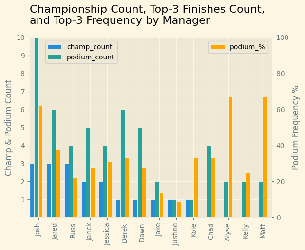

As far as finishing placement goes it's hard to argue against Josh being the best. Tied for the most championships and 4 more podium finishes then the next closest he's top 3 more often than not. Alyse is the only other active manager that has finished top 3 more often than not with 2 out of 3 seasons.

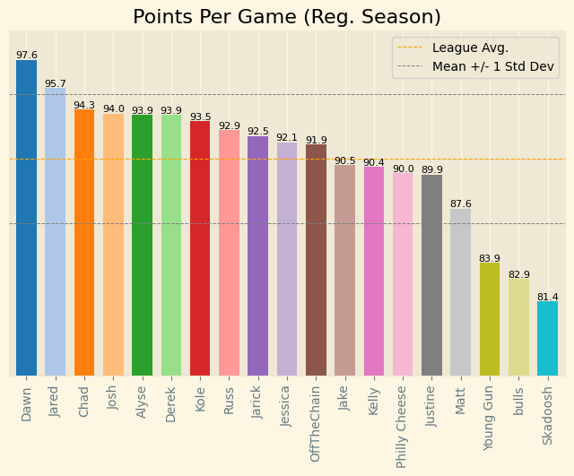

Dawn has dominated in overall PPG during the regular season. She is 1.5 standard deviations above the average and averaging almost 2 pts more than the next highest, Jared, over the history of the league. The 3rd and 11th place teams are seperated by just 2.4 while Dawn is 3.3 pts above the 3rd place team.

Here is another visualization of points scored by manager. This time in the form of a swarmplot. This shows the number of times each manager finished a season (playoff games not included) at each points ranking. This is also a good way to see the count of scoring titles by each manager.

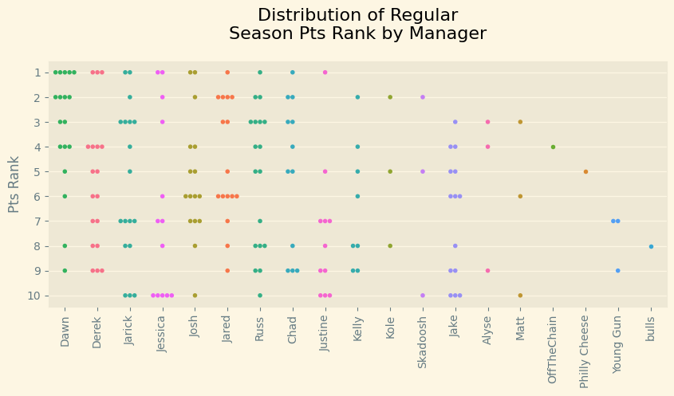

Again it's clear that Dawn is by far the best points scorer in the regular season with a total of five scoring titles and four second place finishes giving nine top-2 finishes. That is four more than the next closest, Jared, at five top-2 and only one first-place finish. Not only that but she has also only finished in the bottom half of the league 3 times in 18 seasons. Most every other manager is at least close to symmetrical in their distribution. Justine skews more towards the bottom of the league but does have one scoring title. Jessica has the most last-place finishes for points but does have two scoring titles - more than Jared and Russ who both have more championships.

This is a heatmap of the league standings each year. Red = good, Blue = bad.

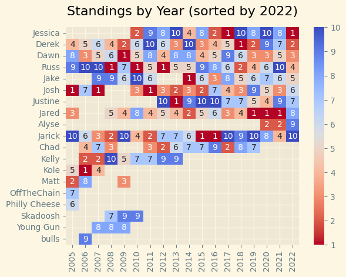

Visualizing the final standings by year we can see there have only been two instances of championship streaks - Jared from 2019-2021 and Jarick in 2015-2016. Also, not a streak, but Russ had an impressive 3 wins in 5 years from 2008-2012.

Another heatmap. This one showing the amount of regular season wins by year.

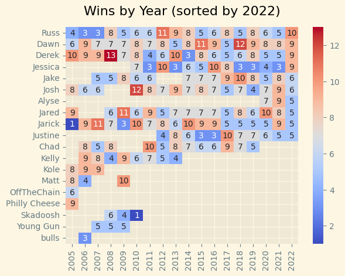

The single season record for wins is held by Derek in 2008 with 13. There have only been two 12-win-seasons: Dawn 2018, and Josh 2010. There have also only been two 1-win-seasons: Jarick in the first season of the league and Skadoosh in 2010.

This is a swarmplot showing how many times each manager won x-amount of games in the regular season. It's similar to the heatmap but instead of seeing it grouped by year we can see the most frequent amounts of wins by a given manager.

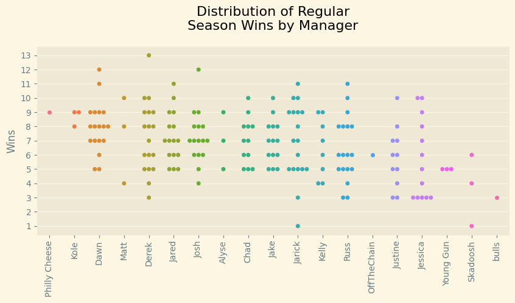

Again here we see the outliers, Derek had a 13 win season, Jarick and Skadoosh each had a 1 win season. Also notably, Dawn, Jared, Alyse, and Jake (of active managers) have never had fewer than 5 wins.

Similar to the previous, this swarmplot shows the count of each specific finish order by manager.

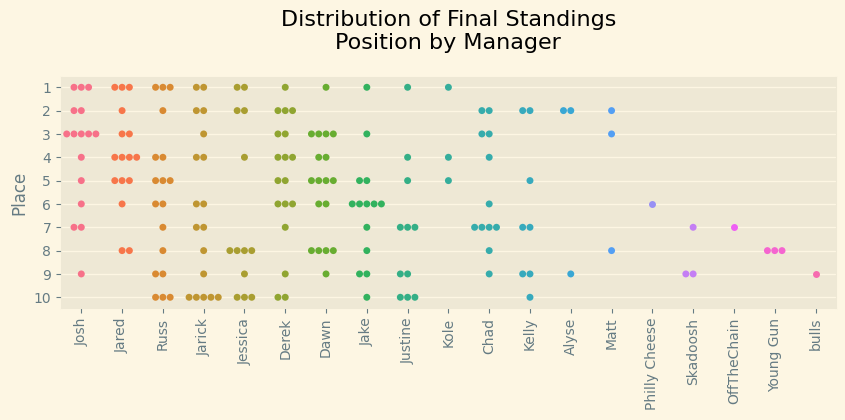

This clearly shows how Josh seems to find his way into the top-3 most years. Five finishes at any given position is the most by anyone, Josh has done it in 3rd place, Jake has done it with 6th place, and embarrassingly, Jarick has done it with 10th place.

This table shows the top-3 finishers in each season year along with their playoff seed.

| finish_order season_year | 1 | 2 | 3 |
| --- | --- | --- | --- |
| 2022 | Phoeber Fever (2) | Reign Man (4) | Powder Puffs (3) |
| 2021 | Shakedown (4) | Team Try Hard (3) | Destroyers (1) |
| 2020 | Shakedown (1) | Team Try Hard (3) | Powder Puffs (2) |
| 2019 | Shakedown (6) | Reign Man (4) | Powder Puffs (1) |
| 2018 | Reign Man (7) | Four and Out (8) | Destroyers (4) |
| 2017 | Phoeber Fever (4) | BABAGANOOSH (3) | Shakedown (7) |
| 2016 | Jagged Edge XIII (3) | Phoeber Fever (1) | El Jefe (5) |
| 2015 | Jagged Edge XII (2) | Destroyers (4) | Reign Man (3) |
| 2014 | Yucatecos (6) | Shakedown (5) | Destroyers (7) |
| 2013 | The Rookies (5) | Destroyers (2) | Reign Man (1) |
| 2012 | Four and Out (1) | BABAGANOOSH (7) | Team Winbig (5) |
| 2011 | Ochoseis (3) | Jagged Edge VIII (4) | BABAGANOOSH (1) |
| 2010 | Four and Out (6) | Hawaii Dreamin (5) | Fuzz (1) |
| 2009 | Powder Puffs (5) | Reign Man (6) | Wyoming Frenzies IV (2) |
| 2008 | Four and Out (2) | Jagged Edge V (4) | Babaganoosh (3) |
| 2007 | The_d3$tRoy*rS_remix (6) | Studmuffin (4) | Jagged Edge IV (1) |
| 2006 | Kolnan's Barbarians (4) | studmuffin (2) | Powder Puffs (1) |
| 2005 | Destroyers Part Deux (6) | Wyoming Frenzies (4) | Shakedown (2) |

The biggest underdog winner was Derek in 2018 when he went into the playoffs as a 7-seed. There have been several 6-seed winners (many of the years the playoffs only included 6 teams) and Russ made it to the championship in 2018 as an 8 seed only to lose to the 7-seed Derek. Oddly enough it looks as though being the 1-seed may not be such a great thing as the 1-seed has only won twice - Jared in 2020 and Russ in 2012. Not only that but Jessica is the only other 1-seed to even make it to the championship and lost to Jarick in 2016.

Next up is a barchart showing total playoff games, wins, losses, and win% by manager.  
This chart only includes the winners-bracket games. The 3rd place and lower games are not counted here as playoff games.

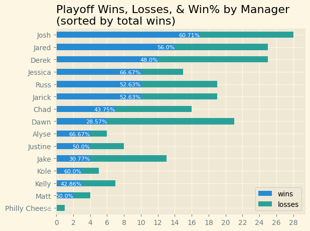

Unsurprisingly, based on the number of championships and top-3 finishes, Josh and Jared do very well in the playoffs. Josh with 17 playoff wins and a 61% win rate. While they have fewer seasons under their belt, Jessica and Alyse have both won two-thirds of the playoff games they've been in. Sadly for Jake and Dawn, they have had playoff struggles only winning about 30% of their games. Dawn has been to the 4th most playoff games and only won the 8th most.

Here we have an estimation of the top 10 "luckiest schedule" seasons. This was calculated by taking the pts scored each week by every team and comparing it to the pts scored of every other team each week and seeing what a perfectly fair week would have looked like. Essentially, each team was simulated in 9 games each week instead of just 1 and their sim_win% (simulated win percentage) was calculated based off those wins, losses, and ties. That was then compared to their actual winning % to see the difference. These are the top 10 largest differences in those percentages which favored a team that, in a simulated season, should have faired much worse than they did.

|  | season_year | wins | losses | ties | manager_name | reg_season_rank | win_% | sim_win% | real_vs_sim | sim_seas_rnk | finish_order |
| --- | --- | --- | --- | --- | --- | --- | --- | --- | --- | --- | --- |
| 0 | 2017 | 9 | 5 | 0 | Chad | 3.0 | 64.29 | 35.32 | 28.97 | 9.0 | 2 |
| 1 | 2019 | 8 | 5 | 0 | Derek | 4.0 | 61.54 | 42.74 | 18.80 | 8.0 | 2 |
| 2 | 2009 | 10 | 4 | 0 | Matt | 2.0 | 71.43 | 52.78 | 18.65 | 7.0 | 3 |
| 3 | 2005 | 8 | 6 | 0 | Josh | 5.0 | 57.14 | 45.24 | 11.90 | 8.0 | 1 |
| 4 | 2011 | 8 | 6 | 0 | Josh | 3.0 | 57.14 | 46.03 | 11.11 | 6.0 | 1 |
| 5 | 2007 | 6 | 7 | 1 | Josh | 6.0 | 46.43 | 36.51 | 9.92 | 10.0 | 1 |
| 6 | 2014 | 7 | 7 | 0 | Jared | 5.0 | 50.00 | 42.06 | 7.94 | 9.0 | 2 |
| 7 | 2014 | 7 | 7 | 0 | Josh | 7.0 | 50.00 | 42.06 | 7.94 | 10.0 | 3 |
| 8 | 2020 | 6 | 6 | 1 | Justine | 6.0 | 50.00 | 43.16 | 6.84 | 9.0 | 4 |
| 9 | 2019 | 6 | 7 | 0 | Jared | 6.0 | 46.15 | 42.74 | 3.41 | 9.0 | 1 |

Chad had by far the luckiest season in 2017 winning 64% of his games when the simulation had him only winning 35% taking him from  
a 3-seed to out of the playoffs.  
Interestingly, Josh shows up 4 times on this list. Based on this alone it's inconclusive whether this really means he has been "lucky" more often than other players or that he is really good in the playoff weeks and simply takes advantage of making it in. Jared's last entry (for 2019) is unique in that his real vs simulated win% difference was only 3.4% - seemingly negligible - and yet in a simulated season he finished 9th which would have kicked him out of the playoffs. Instead, he won it all. Similar to Josh in 2007 and 2005, but those real_vs_sim differences are much more substantial.

The converse of the above table is the most "unlucky schedule" seasons. There are only 6 seasons that qualified for this based on how big an impact the actual win% vs the sim_win% made in the final results.

|  | season_year | wins | losses | ties | manager_name | reg_season_rank | win_% | sim_win% | real_vs_sim | sim_seas_rnk | finish_order |
| --- | --- | --- | --- | --- | --- | --- | --- | --- | --- | --- | --- |
| 0 | 2009 | 4 | 10 | 0 | Skadoosh | 9.0 | 28.57 | 56.75 | -28.18 | 3.0 | 9 |
| 1 | 2019 | 5 | 8 | 0 | Chad | 7.0 | 38.46 | 63.25 | -24.79 | 2.0 | 7 |
| 2 | 2017 | 5 | 9 | 0 | Josh | 7.0 | 35.71 | 59.52 | -23.81 | 3.0 | 4 |
| 3 | 2019 | 4 | 9 | 0 | Josh | 9.0 | 30.77 | 50.43 | -19.66 | 5.0 | 9 |
| 4 | 2013 | 5 | 8 | 1 | Dawn | 8.0 | 39.29 | 55.95 | -16.66 | 4.0 | 8 |
| 5 | 2015 | 6 | 8 | 0 | Chad | 7.0 | 42.86 | 58.73 | -15.87 | 3.0 | 7 |

Skadoosh and Chad had very bad luck in 2009 and 2019, respectively, finishing out of the playoffs when they should have been closer to 3 and 2-seeds. Josh somehow is the most frequently unlucky and lucky so it seems to even out to some extent.

These are the head to head regular season records for every current manager against one another. The rows are the opponent and the columns are team in question. E.g. Dawn is 15-12-0 against Jared, 18-11-1 against Russ etc. Jared is 12-15-0 against Dawn, 16-11-0 against Jarick etc. They are highlighted based on win%. Darker means a better win% against that opponent.

|  | Dawn | Jared | Russ | Jarick | Josh | Derek | Jake | Jessica | Justine | Alyse |
| --- | --- | --- | --- | --- | --- | --- | --- | --- | --- | --- |
| Dawn | nan | 12-15-0 | 11-18-1 | 11-22-1 | 14-17-0 | 17-15-0 | 10-7-1 | 5-15-0 | 2-9-0 | 1-4-0 |
| Jared | 15-12-0 | nan | 13-13-0 | 11-16-0 | 9-9-0 | 20-9-0 | 6-12-0 | 12-11-0 | 6-12-1 | 2-4-0 |
| Russ | 18-11-1 | 13-13-0 | nan | 10-16-0 | 17-9-0 | 11-10-0 | 13-12-0 | 10-7-1 | 10-7-0 | 3-4-0 |
| Jarick | 22-11-1 | 16-11-0 | 16-10-0 | nan | 13-13-0 | 10-18-1 | 11-15-0 | 4-12-2 | 7-8-0 | 2-1-0 |
| Josh | 17-14-0 | 9-9-0 | 9-17-0 | 13-13-0 | nan | 8-12-0 | 13-7-0 | 6-11-0 | 8-11-1 | 3-3-0 |
| Derek | 15-17-0 | 9-20-0 | 10-11-0 | 18-10-1 | 12-8-0 | nan | 16-8-0 | 7-16-1 | 7-13-0 | 2-2-0 |
| Jake | 7-10-1 | 12-6-0 | 12-13-0 | 15-11-0 | 7-13-0 | 8-16-0 | nan | 8-11-1 | 7-4-0 | 3-3-0 |
| Jessica | 15-5-0 | 11-12-0 | 7-10-1 | 12-4-2 | 11-6-0 | 16-7-1 | 11-8-1 | nan | 9-11-1 | 3-1-0 |
| Justine | 9-2-0 | 12-6-1 | 7-10-0 | 8-7-0 | 11-8-1 | 13-7-0 | 4-7-0 | 11-9-1 | nan | 3-2-1 |
| Alyse | 4-1-0 | 4-2-0 | 4-3-0 | 1-2-0 | 3-3-0 | 2-2-0 | 3-3-0 | 1-3-0 | 2-3-1 | nan |

You'd think this would be pretty random and that head to head records would even out especially over a lot of games but there are some pretty lopsided records here. Dawn (unsurprisingly based on her regular season records and pts) has a very good win % against most teams but here kryptonite seems to be Jake. She only has losing record to Jake and Derek with Jake being the tougher opponent percentage-wise.  
Jake is actually the the most frequent kryptonite-team with 3 instances: against Dawn, Josh, and Derek. On the flip side he is Jared and Justine's easiest opponent.  
The most surprisingly lopsided matchups are Derek beating Jared 20-9 and Dawn beating Jarick 22-11-1 - which happens to be the most times one manager has beaten another.

Here is the same style table but with playoff records. It's more difficult to see patterns since the sample size is smaller but it's still interesting to see who has trouble against who in the playoff weeks.

|  | Dawn | Jared | Russ | Jarick | Josh | Derek | Jake | Jessica | Justine | Alyse |
| --- | --- | --- | --- | --- | --- | --- | --- | --- | --- | --- |
| Dawn | nan | 1-1-0 | 2-0-0 | 2-0-0 | 1-1-0 | 3-2-0 | 1-1-0 | 1-1-0 | nan | 1-0-0 |
| Jared | 1-1-0 | nan | 1-3-0 | nan | 4-1-0 | 1-1-0 | 2-2-0 | 0-1-0 | 0-1-0 | 0-2-0 |
| Russ | 0-2-0 | 3-1-0 | nan | 0-2-0 | 1-2-0 | 2-0-0 | nan | 2-1-0 | nan | 1-0-0 |
| Jarick | 0-2-0 | nan | 2-0-0 | nan | 3-2-0 | 0-3-0 | nan | 1-1-0 | nan | 1-0-0 |
| Josh | 1-1-0 | 1-4-0 | 2-1-0 | 2-3-0 | nan | 0-1-0 | 1-0-0 | 2-0-0 | 2-1-1 | nan |
| Derek | 2-3-0 | 1-1-0 | 0-2-0 | 3-0-0 | 1-0-0 | nan | 0-3-0 | 2-0-0 | 1-1-0 | nan |
| Jake | 1-1-0 | 2-2-0 | nan | nan | 0-1-0 | 3-0-0 | nan | 1-0-0 | nan | 1-0-0 |
| Jessica | 1-1-0 | 1-0-0 | 1-2-0 | 1-1-0 | 0-2-0 | 0-2-0 | 0-1-0 | nan | nan | nan |
| Justine | nan | 1-0-0 | nan | nan | 1-2-1 | 1-1-0 | nan | nan | nan | nan |
| Alyse | 0-1-0 | 2-0-0 | 0-1-0 | 0-1-0 | nan | nan | 0-1-0 | nan | nan | nan |